# Practica IRT Coneval

2025-10-30

```r
library(latticeExtra)
library(mirt)
```

```r
library(ggplot2)
library(gridExtra)
library(pracma)
```

# Segundo ejemplo

Ahora vamos hacer estimaciones de TRI considerando el índice de seis carencias del CONEVAL. Para ello utilizaremos los datos 2018.

```r
library(haven)
D18<-read_dta("pobreza_18sample.dta")
```

El modelo del CONEVAL no parece pensar a las carencias en términos exclusivos de diferencias en severidad. Noten que también se pueden pasar los nombres de las variables. Con la función `coef()` se extraen los valores de la discriminación “a” y de la severidad “b”. Hay valores un tanto bajos: ic_rezedu, ic_asalud, ic_ali.

```r
m3<-mirt(D18[,c("ic_rezedu", "ic_asalud", "ic_segsoc", "ic_sbv", "ic_ali", "ic_cv")], 1, itemtype = '2PL', weights=D18$factor)
```

```r
coef(m3, IRTpars = T, simplify = T)
```

```
## $items
##               a      b g u
## ic_rezedu 0.818  1.346 0 1
## ic_asalud 0.523  3.761 0 1
## ic_segsoc 0.968 -0.118 0 1
## ic_sbv    2.392  0.969 0 1
## ic_ali    0.846  1.864 0 1
## ic_cv     1.580  1.972 0 1
##
## $means
## F1
##  0
##
## $cov
##    F1
## F1  1
```

Podemos graficar los resultados de la siguiente manera con `ggplot2`

```r
plt <- plot(m3, type = 'trace', facet_items=FALSE)
pltdata <- data.frame(lapply(plt$panel.args, function(x) do.call(cbind, x))[[1]])
pltdata$item <- rep(c("ic_rezedu", "ic_asalud", "ic_segsoc", "ic_sbv", "ic_ali", "ic_cv"), each = 200)
head(pltdata)
```

```
##           x           y subscripts      item
## 1 -6.000000 0.002452917          1 ic_rezedu
## 2 -5.939698 0.002576604          2 ic_rezedu
## 3 -5.879397 0.002706511          3 ic_rezedu
## 4 -5.819095 0.002842949          4 ic_rezedu
## 5 -5.758794 0.002986244          5 ic_rezedu
## 6 -5.698492 0.003136740          6 ic_rezedu
```

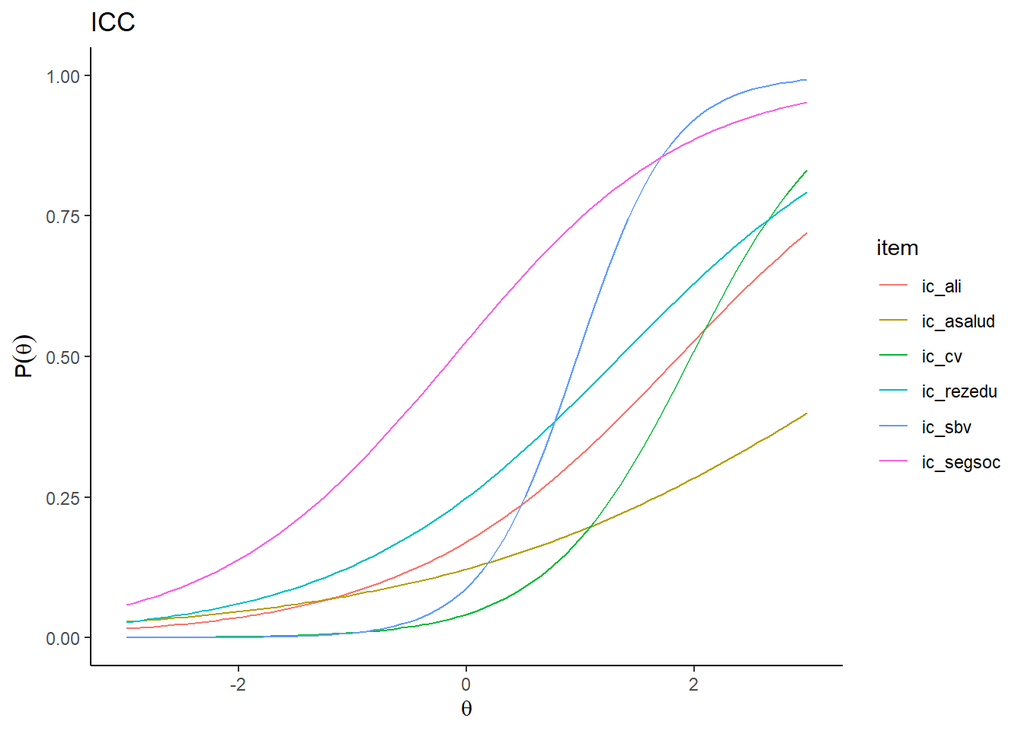

```r
library(ggplot2)
ggplot(pltdata, aes(x, y, colour=item)) + geom_line() + ggtitle('ICC') +
    xlab(expression(theta)) + ylab(expression(P(theta))) + xlim(c(-3,3)) + theme_classic()
```

Ahora calculamos la curva total de información. La curva luce bastante baja. Mostrando la poca información que existe en el índice de carencias.

```r
areainfo(m3, c(-3,0), which.items = 1:6)
```

```
##  LowerBound UpperBound     Info TotalInfo Proportion nitems
##          -3          0 1.098308  7.128435  0.1540742      6
```

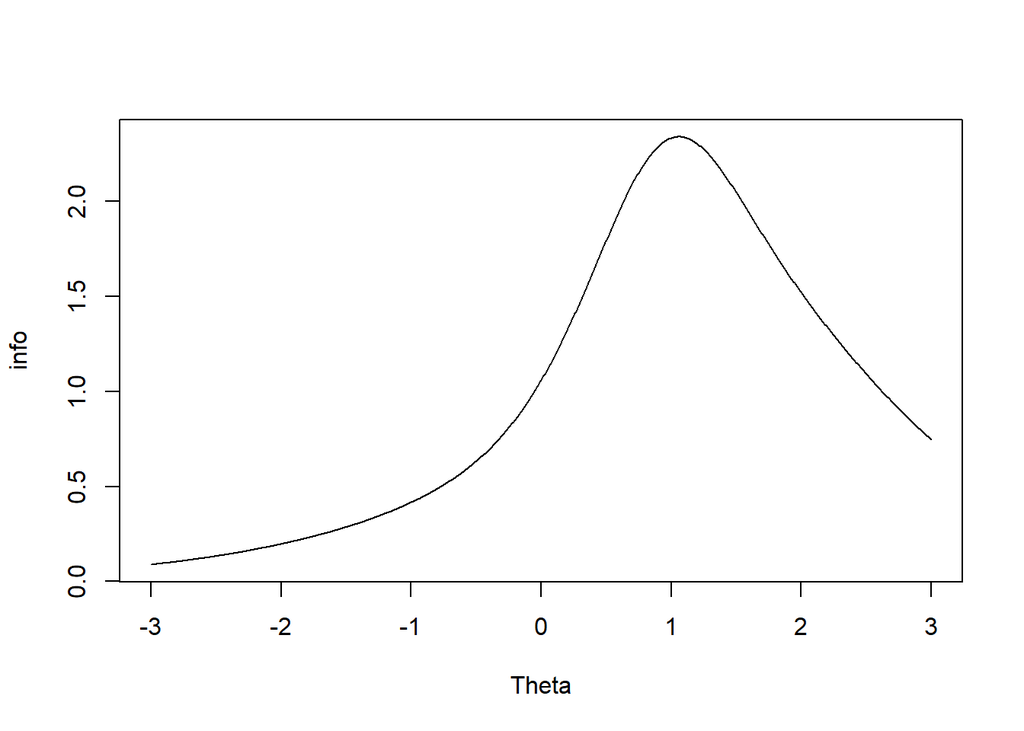

```r
Theta <- matrix(seq(-3,3, length.out=1000))
info <- testinfo(m3, Theta)
plot(info ~ Theta, type = 'l')
```

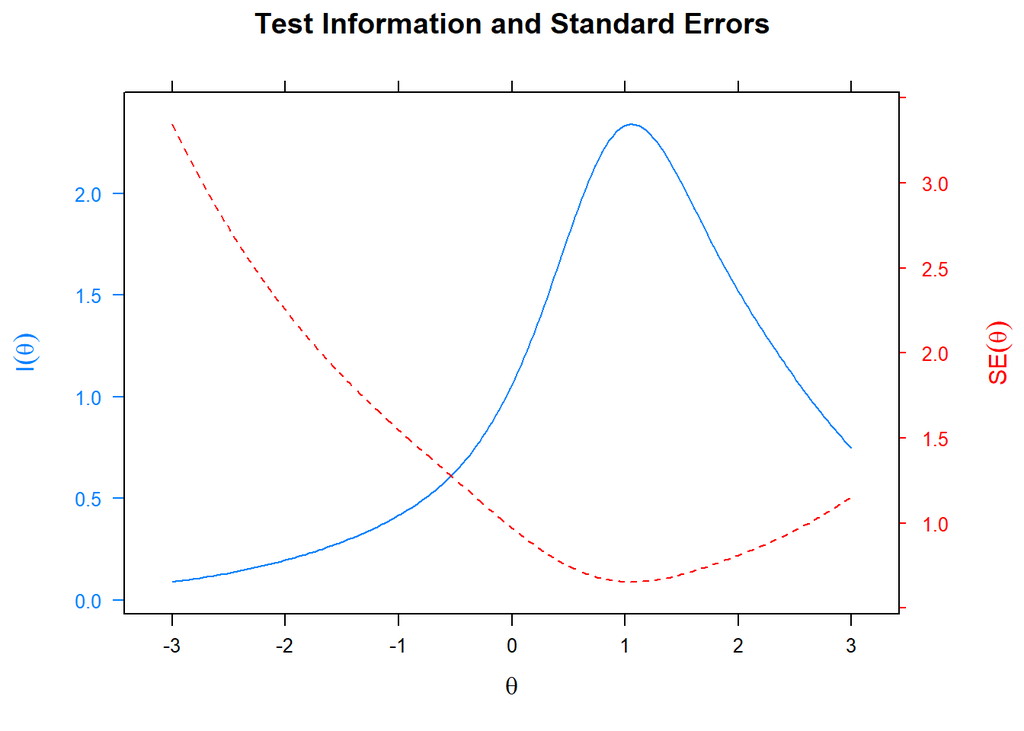

```r
plot(m3, type = 'infoSE', theta_lim = c(-3,3))
```

## Aplicando los análisis avanzados al modelo CONEVAL

Veamos cómo se comportan estos mismos análisis con el índice de carencias del CONEVAL:

```r
# Análisis rápido de la relación score-theta para CONEVAL
cat("\n=== ANÁLISIS CONEVAL: RELACIÓN SCORE-THETA ===\n")
```

```
##
## === ANÁLISIS CONEVAL: RELACIÓN SCORE-THETA ===
```

```r
# Calcular scores y thetas
scores_coneval <- rowSums(D18[,c("ic_rezedu", "ic_asalud", "ic_segsoc", "ic_sbv", "ic_ali", "ic_cv")])
theta_coneval_matrix <- fscores(m3, method = "EAP", full.scores = TRUE)

# Extraer solo los valores de theta
if(is.matrix(theta_coneval_matrix)) {
  theta_coneval <- theta_coneval_matrix[,1]
} else {
  theta_coneval <- as.vector(theta_coneval_matrix)
}

df_coneval <- data.frame(
  score = scores_coneval,
  theta = theta_coneval
)

# Tabla de conversión
tabla_coneval <- aggregate(theta ~ score, df_coneval,
                          function(x) c(mean = round(mean(x), 3),
                                      n = length(x)))
tabla_coneval <- do.call(data.frame, tabla_coneval)
colnames(tabla_coneval) <- c("Num_Carencias", "Theta_Medio", "N")

print(tabla_coneval)
```

```
##   Num_Carencias Theta_Medio    N
## 1             0      -0.786 2814
## 2             1      -0.219 2873
## 3             2       0.292 2302
## 4             3       0.854 1285
## 5             4       1.354  540
## 6             5       1.783  164
## 7             6       2.132   22
```

[figure not shown]

```r
# Gráfico comparativo
p_coneval <- ggplot(df_coneval, aes(x = score, y = theta)) +
  geom_jitter(alpha = 0.2, width = 0.1, height = 0) +
  geom_smooth(method = "loess", se = TRUE, color = "red") +
  labs(title = "Relación Score-Theta: Índice de Carencias CONEVAL",
       subtitle = "Nota la menor información comparado con EMSA",
       x = "Número de Carencias",
       y = expression(theta)) +
  theme_minimal() +
  scale_x_continuous(breaks = 0:6)

print(p_coneval)
```

```r
tabscores <- fscores(m3, full.scores = FALSE)
```

```
##
## Method:  EAP
##
## Empirical Reliability:
##
##    F1
## 0.507
```

```r
head(tabscores)
```

```
##      ic_rezedu ic_asalud ic_segsoc ic_sbv ic_ali ic_cv          F1     SE_F1
## [1,]         0         0         0      0      0     0 -0.78580429 0.7899605
## [2,]         0         0         0      0      0     1  0.06253748 0.6767791
## [3,]         0         0         0      0      1     0 -0.29863002 0.7271481
## [4,]         0         0         0      0      1     1  0.42268919 0.6300218
## [5,]         0         0         0      1      0     0  0.40911368 0.6316146
## [6,]         0         0         0      1      0     1  0.98593401 0.5861056
```

# Test scores y escalamiento en TRI

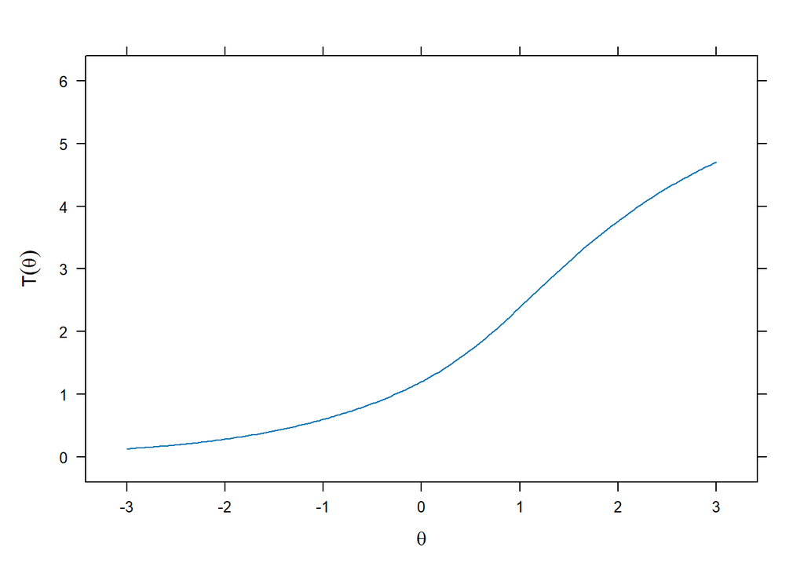

```r
plot(m3, type = 'score', theta_lim = c(-3, 3), main = "")
```

# Extras: ¿Qué pasa si incluimos la pobreza por ingresos?

```r
m4<-mirt(D18[,c("ic_rezedu", "ic_asalud", "ic_segsoc", "ic_sbv", "ic_ali", "ic_cv", "plb_m")], 1, itemtype = '2PL', weights=D18$factor)
```

```r
coef(m4, IRTpars = T, simplify = T)
```

```
## $items
##               a      b g u
## ic_rezedu 0.862  1.293 0 1
## ic_asalud 0.493  3.971 0 1
## ic_segsoc 0.999 -0.115 0 1
## ic_sbv    2.164  1.005 0 1
## ic_ali    0.888  1.797 0 1
## ic_cv     1.608  1.953 0 1
## plb_m     1.319  1.766 0 1
##
## $means
## F1
##  0
##
## $cov
##    F1
## F1  1
```

```r
anova(m4, m3)
```

```
##         AIC    SABIC       HQ      BIC    logLik       X2 df p
## m4 65109.27 65165.72 65143.43 65210.21 -32540.63
## m3 57802.16 57850.55 57831.45 57888.69 -28889.08 7303.104 62 0
```

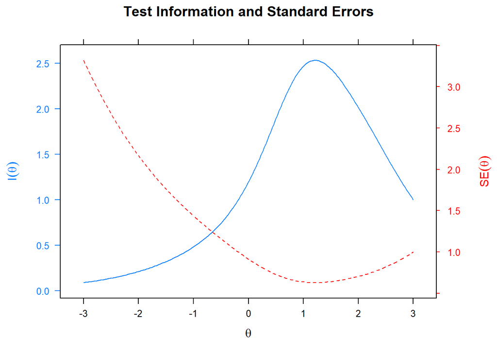

```r
plot(m4, type = 'infoSE', theta_lim = c(-3,3))
```

# Extras: Estimación del ajuste de cada indicador.

La función itemfit muestra los cambios en $\chi^2$ atribuibles a los indicadores y el valor de RMSEA por indicador. Estos estadísticos pueden usarse para identificar items problemáticos en el contexto del modelo estimado. Valores de RMSEA.S_X2>.05 indican un pobre ajuste.

```r
itemfit(m3)
```

```
##        item    S_X2 df.S_X2 RMSEA.S_X2 p.S_X2
## 1 ic_rezedu 111.032       3      0.060  0.000
## 2 ic_asalud 377.609       3      0.112  0.000
## 3 ic_segsoc   5.356       3      0.009  0.148
## 4    ic_sbv   4.284       3      0.007  0.232
## 5    ic_ali  21.497       3      0.025  0.000
## 6     ic_cv   8.707       3      0.014  0.033
```